# Shiny: Operations With Dynamically Created Inputs

[Heitor Gabriel S. Monteiro](https://sites.google.com/view/heitor-gabriel-monteiro/p%C3%A1gina-inicial)

2022-09-11

In this post, I make an Shiny app that allows the user to choose the quantity of the terms that will be made part of some exemplar operation with data as follows:

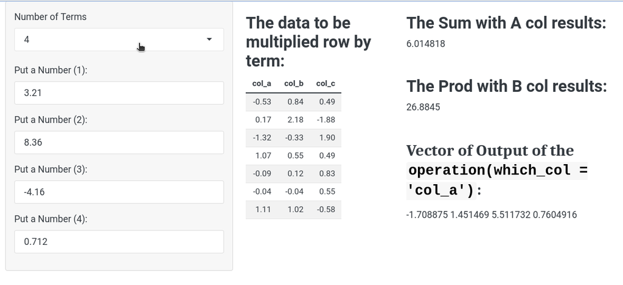

The challenge is to cover in some operation the new variables made by the user.  
Firstly, I built a basic structure of the app in the User Interface (UI) part, following the Sidebar Layout with two columns. Just for perfumery, I put a theme provided by `bslib` package:

```r
ui <- fluidPage( theme =  bslib::bs_theme(bootswatch = "litera"),
    sidebarLayout(
    sidebarPanel(
        "sidebar content..."
    ),
    mainPanel(
        fluidRow(
            column(width = 4, "Column content..."),
            column(width = 6, "Column content..."))
    )
))  # end of the sidebarLayout and fluidPage
```

Now, create the quantities’ selector of terms by the user with `selectInput( inputId="qntt_terms", ...`. **It needs to be chosen before the terms’ value because it restarts the field without saving the value if it is filled.** So, in this example, the user can’t write the value and click to add one more field. In my example, I will make the first term independent of the selector, understanding the idea, you can put it in the selector’s function of creation of terms. So, the first input is `numericInput( inputId="term_1", ...` and the space to the new terms is the dynamic UI `uiOutput("new_terms")`.

```r
ui <- fluidPage( theme =  bslib::bs_theme(bootswatch = "litera"),
    sidebarLayout(
    sidebarPanel(
        selectInput("qntt_terms",
                        label = "Number of Terms",
                        choices = 1:7,
                        selected = 1),
        numericInput("term_1", "Put a Number (1):", 0),
        uiOutput("new_terms")
    ),
    mainPanel(
        fluidRow(
            column(width = 4, "Column content..."),
            column(width = 6, "Column content..."))
    )
))  # end of the sidebarLayout and fluidPage
```

Now, make the server part. The named earlier dynamic UI `new_terms` will be made by `new_t()` reactive operation:

```r
server <- function(input, output, session) {

    new_t <- reactive({
        "counter and terms' creator"
    })       # end of the reactive

    output$new_terms <- renderUI({ new_t() })
}
```

The `new_t()` takes `qntt_terms` as the number of times that will be printed the same numeric input that the `term_1` but making new names to this new fields with the `lapply(2:n, function(i){ ...inputId=paste0("term_",i)... }` structure. The `if(n>1){...}` is because I let the first term independent and it will run only since two:

```r
server <- function(input, output, session) {

new_t <- reactive({
        n <- input$qntt_terms |> as.numeric()
        if(n>1){
            lapply(2:n, function(i) {
                br()
                numericInput(inputId = paste0("term_",i),
                                 label = paste0("Put a Number (", i,"):"), 0)
            }) # end of the function and lapply
        }     # end of the if(n>1)
    })

    output$new_terms <- renderUI({ new_t() })
}
```

I create this new example data to make part of the operations with the new terms:

```r
data_ex <- tibble("col_a" = rnorm(7),
                      "col_b" = rnorm(7),
                      "col_c" = rnorm(7))
```

Now, still in server part, make the function `operation(wich_col)` that handle all the i= 1,…, n terms by `input[[paste0("term_",i)]]`. This is the core of the idea of operations with dynamically created variables.

`for (i in 1:req(input$qntt_terms)) {... input[[paste0("term_",i)]] ...}`

In this example, I make a multiplication with the correspondent *i-th* row of the `wich_col` data column. It returns a vector of results.

```r
operation <- function(which_col){
        temp_vect <- vector()
        for (i in 1:req(input$qntt_terms)) {
            temp_vect[i] <-
                req(input[[paste0("term_",i)]]) *
                data_ex |> pull(which_col) |> nth(i)
        }
        return(temp_vect)
    }
```

In first column of main panel, I show the data with `tableOutput("data_ex_call")` in UI part that requires an `output$data_ex_call <- renderTable()` in server part. In the second column, I print some uses of the created function. Join server, ui, and the data, we have:

```r
library(shiny)
library(bslib)
library(tidyverse)

data_ex <- tibble("col_a" = rnorm(7),
                      "col_b" = rnorm(7),
                      "col_c" = rnorm(7))

ui <- fluidPage( theme =  bslib::bs_theme(bootswatch = "litera"),
    sidebarLayout(
    sidebarPanel(
        selectInput("qntt_terms",
                        label = "Number of Terms",
                        choices = 1:7,
                        selected = 1),
        numericInput("term_1", "Put a Number (1):", 0),
        uiOutput("new_terms")
    ),
    mainPanel(
        fluidRow(
            column(width = 4, "The data to be multiplied row by term:" |> h3(),
                     tableOutput("data_ex_call")),
            column(width = 6,
                     "The Sum with A col results:" |> h3(),
                     textOutput("sum_a_terms"),
                     br(),
                     "The Prod with B col results:" |> h3(),
                     textOutput("prod_b_terms"),
                     br(),
                     markdown("Vector of Output of the `operation(which_col = 'col_a')`:") |> h3(),
                     textOutput("test_of_func")
    ))
    )
))  # end of the sidebarLayout and fluidPage

server <- function(input, output, session) {

    new_t <- reactive({
        n <- input$qntt_terms |> as.numeric()
        if(n>1){
            lapply(2:n, function(i) {
                br()
                numericInput(inputId = paste0("term_",i),
                                 label = paste0("Put a Number (", i,"):"), 0)
            }) # end of the function and lapply
        }     # end of the if(n>1)
    })       # end of the reactive

    output$new_terms <- renderUI({ new_t() })

    operation <- function(which_col){
        temp_vect <- vector()
        for (i in 1:req(input$qntt_terms)) {
            temp_vect[i] <-
                req(input[[paste0("term_",i)]]) *
                data_ex |> pull(which_col) |> nth(i)
        }
        return(temp_vect)
    }

    output$sum_a_terms <- renderText({
        operation(which_col = "col_a") |> sum()
    })
    output$prod_b_terms <- renderText({
        operation(which_col = "col_b") |> prod()
    })
    output$test_of_func <- renderText({
        operation(which_col = "col_a")
    })

    output$data_ex_call <- renderTable({data_ex},
                                                  striped = TRUE,
                                                  digits = 2)

}

shinyApp(ui, server)
```

This is the app:

[interactive chart not shown]

I thanks any commentary and helps. Finally, I thanks to the socialscientist to help me with this issue.